# Introduction to R

EC 320: Introduction to Econometrics University of Oregon

Winter 2022

## Installation

Having R and R Studio on your laptop will allow you to work on problem sets and explore the magnificent functionality of R outside the lab. R is the language and R Studio helps us interact with R. It is important that you **install R before you install R Studio.**

### Install R

In your web browser,

- Go to r-project.org
- Click [download R](https://cran.r-project.org/mirrors.html).
- At this point, you’ll be directed to a page with a list of institutions that host the Comprehensive R Archive Network (CRAN). The idea is to pick an institution near you. Scroll down to USA and click the link for [OSU](https://ftp.osuosl.org/pub/cran/).

**Windows Instructions:** If you have a Windows machine,

- Click `Download R for Windows`
- Click `install R for the first time`
- Click `Download R 4.1.2 for Windows`
- To complete installation, run the `.exe` file you downloaded.

**Mac Instructions:** If you have a Mac,

- Click `Download R for (Mac) OS X`
- Under “latest release”, click `R-4.1.2.pkg` if your mac has **Intel chip**
- Click `R-4.1.2-arm64.pkg` if your mac has **Apple silicon chip**
- To complete installation, run the `.pkg` file you downloaded.

**Make sure you download different package depending on the type of chip your Mac has.**

**Linux Instructions:** If you run a Linux distro, note that installation instructions vary by distro. That said, you probably know what you’re doing.

### Install RStudio

In your web browser, go to rstudio.com/products/rstudio/, scroll down to R Studio Desktop, and then click [Download RStudio Desktop](https://rstudio.com/products/rstudio/download/) under “Open Source Edition.” Scroll down to “Installers for Supported Platforms” and click the link that corresponds with your operating system. To complete installation, run the installer you downloaded.

## R Basics

### Mechanism that runs RStudio

RStudio is an integrated development environment (IDE) for R. In other words, RStudio is an environment that provides a set of necessary tools for programmers to easily write and execute codes. Because RStudio is just an environment, it won’t run any codes if R is not installed prior to installation of RStudio. Note that technically, all the codes written in scripts run on R, and not RStudio.

### Using the console

When you open R Studio for the first time, you should notice three panels. The large panel to the left is the **console**. This is where you run code that tells R what to do. You can also use the console as a calculator. For example, if you type `5+5*2-1` in the console and hit `Enter`, then R will return

```
## [1] 14
```

in the console.

### Everything is an object

The upper-right panel is the **global environment**. This is where R Studio stores datasets, user-defined functions, and other **objects**.

To define an object, you use the **assignment operator** `<-` or simply `=`.[^1] For example, suppose that you want to assign the number 5 to an object called `a`. In the console, you would type

```r
a <- 5
```

which reads “`a` gets 5.” When you execute this code (by hitting `Enter`), `a` will show up in the global environment. Hovering your cursor over `a` in the global environment tells you that `a` is a numeric object.

There are other kinds of objects, too. For example,

```r
b <- "I Love Metrics"
```

is a character object, and

```r
mat <- matrix(c(1, 2, 3, 4),
              nrow = 2)
```

is a matrix.

### Packages

R functions come in packages. When you open a fresh R session in RStudio, a number of packages come pre-loaded. These include packages with common math and statistics functions and are known collectively as “base R.” Base R is wonderful, but non-default packages offer a great deal of flexibility and functionality.

You could consider a package to be a combined set of multiple packages, or multiple data sets and functions defined by other coders in the R community. For example, one common package that we will use often later in the class is [`tidyverse`](https://www.tidyverse.org/packages/) package. In this package, multiple functions that are useful for data analysis are predefined so that we could simply call a specific function name to use it.

**Install a package:** `install.packages("package.name.here")`

- Replace `package.name.here` with the name of the package you want to install.
- Make sure the name of the package is in quotes.
- You only have to install a package once.

Alternatively, you can click on the `Packages` tab of the bottom-right panel:

[figure not shown]

**Load a package:** `library(package.name.here)`

- To use functions from a non-base package, you need to load the package at the beginning of each new R session.
- Quotes around the package name are no longer needed.

#### **`pacman`**

We will often need to load several packages in a single session. One way to do this is to execute `library(package.1)`, then `library(package.2)`, then `library(package.3)`, and so forth. A less cumbersome way to load multiple packages is to use the `p_load` function from the `pacman` package.

- Use the instructions above to **install `pacman`**.
- Load the `pacman` package with `library(pacman)`.
- When you want to load additional packages, you can then execute `p_load(package.1, package.2, package.3)`.
- **Added bonus:** `p_load` first checks to see if the packages are installed. If they aren’t, then it will install them for you.

### R scripts

To produce reproducible[^2] R code, it is best to use scripts. Open a new R script file with the `.R` extension by clicking `File` then `New File` then `R Script`. We will write our first script to generate a histogram and scatter plot using `ggplot2`.

**For your exercises, you are going to create and submit the knitted version of R scripts.**

### `ggplot2`

Start by writing code to install and load `ggplot2`.

```r
library(pacman)
p_load(ggplot2)
```

- To learn more about the package or the function of your using, simply put `?` in front of the name of the package/function with no space in between the question mark and the name of the package/function.
- To execute *one line of your script*, click the line you want to run and then click `Run` at the upper-right corner of your R script. A quicker alternative is to click the line you want to run and then use the keyboard shortcut `Ctrl` `Enter`.
- To execute *the entire script*, click `Source` at the upper-right corner of your R script or use the keyboard shortcut `Ctrl` `Alt` `R`. You could adjust these hot keys per your taste by selecting `Tools`>`Modify Keyboard Shortcuts...`.

**Aside:** It is useful to leave comments in your code to explain to your future self what your code is doing and why. You can leave a comment by typing a hash `#`. Notice also that when you put `#` in front of a code, R would skip this line and not run that code. This is why when you want to leave a comment, you would want to put a hash `#` in front of it so that R would keep it from running. :

```r
# This is a comment. R will ignore it.
```

Check out the example dataset `midwest` from `ggplot2`. You can view the first few rows of the dataset with variable names by using the `head` function.

```r
head(midwest)
```

```
## # A tibble: 6 × 28
##     PID county   state  area poptotal popdensity popwhite popblack popamerindian
##   <int> <chr>    <chr> <dbl>    <int>      <dbl>    <int>    <int>         <int>
## 1   561 ADAMS    IL    0.052    66090      1271.    63917     1702            98
## 2   562 ALEXAND… IL    0.014    10626       759      7054     3496            19
## 3   563 BOND     IL    0.022    14991       681.    14477      429            35
## 4   564 BOONE    IL    0.017    30806      1812.    29344      127            46
## 5   565 BROWN    IL    0.018     5836       324.     5264      547            14
## 6   566 BUREAU   IL    0.05     35688       714.    35157       50            65
## # … with 19 more variables: popasian <int>, popother <int>, percwhite <dbl>,
## #   percblack <dbl>, percamerindan <dbl>, percasian <dbl>, percother <dbl>,
## #   popadults <int>, perchsd <dbl>, percollege <dbl>, percprof <dbl>,
## #   poppovertyknown <int>, percpovertyknown <dbl>, percbelowpoverty <dbl>,
## #   percchildbelowpovert <dbl>, percadultpoverty <dbl>,
## #   percelderlypoverty <dbl>, inmetro <int>, category <chr>
```

Next, make a histogram of county poverty rates (measured by the variable `percbelowpoverty`) using the `ggplot` function. You will need to tell `ggplot`

- The name of the dataset.
- The name of the variable.
- The type of graph (in this case, `geom_histogram()`).

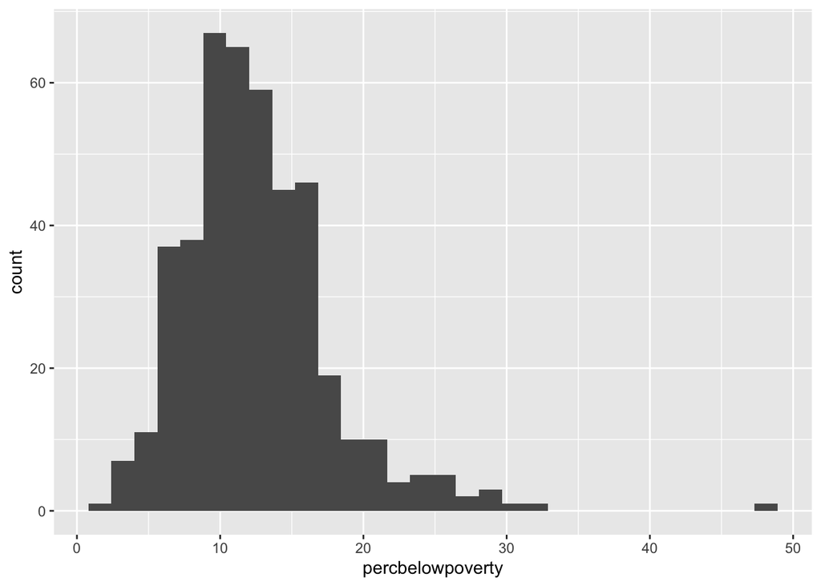

```r
ggplot(data = midwest, aes(x = percbelowpoverty)) +
  geom_histogram()
```

To visualize relationships between variables, you can make a scatter plot. Do poverty rates appear positively or negatively correlated with race, as measured by the variable `percblack`?

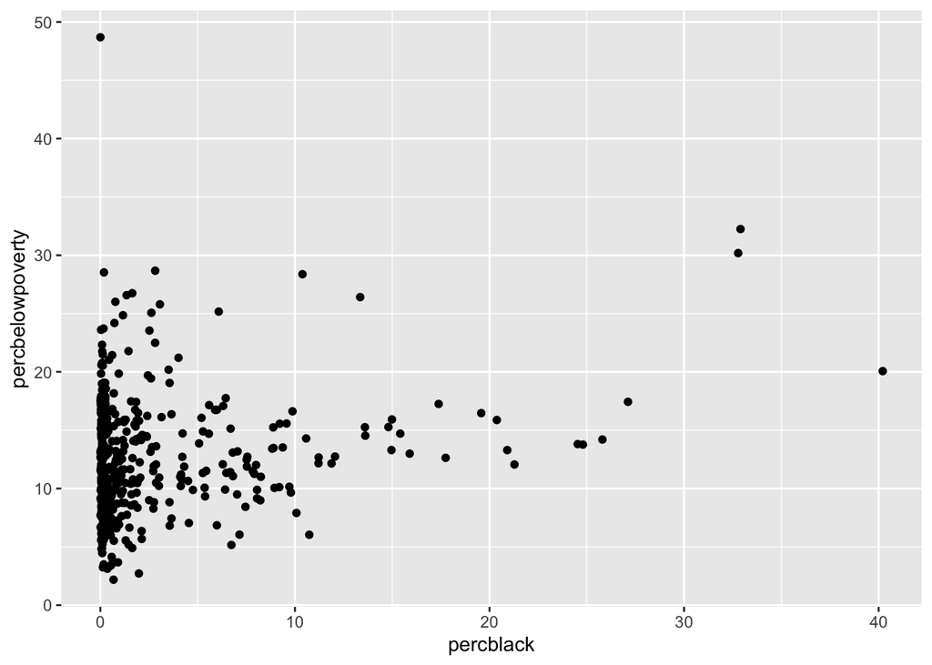

```r
ggplot(data = midwest, aes(x = percblack, y = percbelowpoverty)) +
  geom_point()
```

## Knitting

Knitting a document means that you could turn all the texts and codes written in R script into a nicely formatted document. For now, we are going to turn R script into `.html` document. You could knit your R script into `.html` document by clicking `File`>`Knit Document` or simply use shortcut, `Ctrl` `Shift` `K`. For those of you who cannot see `Knit Document` under `File` tab, you may find something similar to `Compile Document`. Click it and it’ll do the same trick.

## Now your turn

Please open up the `01-Exercise.R` and fill out your answer for each question.

[^1]: **Pro tip:** You can type the assignment operator with the keyboard shortcut `Alt` `-`.
[^2]: Reproducible = fewer headaches later.